# Voronoi To The World

Author

Michael Betancourt

Published

November 2025

Voronoi diagrams arise naturally in various spatial analyses. More importantly for this author, they also tend to be aesthetically attractive, making them useful for crafting compelling illustrations.

Efficiently constructing a Voronoi diagram, however, is not particularly straightforward. In this note I work through the geometric structure of Voronoi diagrams and an algorithm that leverages that structure to construct Voronoi diagrams with the maximum possible performance.

# 1 Tessellating A Plane

A **Voronoi diagram**, also known as a **Dirichlet tessellation**, is an organization of a plane into subsets defined by the nearest proximity to a given collection of points.

From what I can tell the standard reference for Voronoi diagrams, and other topics in computational geometry, is Berg et al. (2008). This text is often referred to as “the 4Ms”, which I can only infer refers to the fact that three out of the four authors share the first name “Mark” with the forth, non-Mark author being an honorary “M”. I humbly suggest that “Mark, Marky, Mark, and the Funky Bunch” is more appropriate, but to each their own.

To formally define a Voronoi diagram consider a two-dimensional Euclidean plane $\mathbb{R}^{2}$ and a collection of **sites**
$$( \, s_{1} = (x_{1}, y_{1}), \ldots, s_{N} = (x_{N}, y_{N}) \, )
\subset \mathbb{R}^{2}.$$
Give a particular site $s_{n}$ we can construct a subset of points that are closer to that site than any other site,
$$\mathsf{c}_{n} =
\{ p \in \mathbb{R}^{2} \mid
d( p, s_{n} ) < d( p, s_{n'} ) \; \mathrm{for all} \; n' \ne n \},$$
where $d(p, p')$ is a distance function. These subsets are also known as **cells**. The Voronoi diagram of $(s_{1}, \ldots, S_{N})$ is the corresponding collection of these proximity-based subsets (Figure 1).

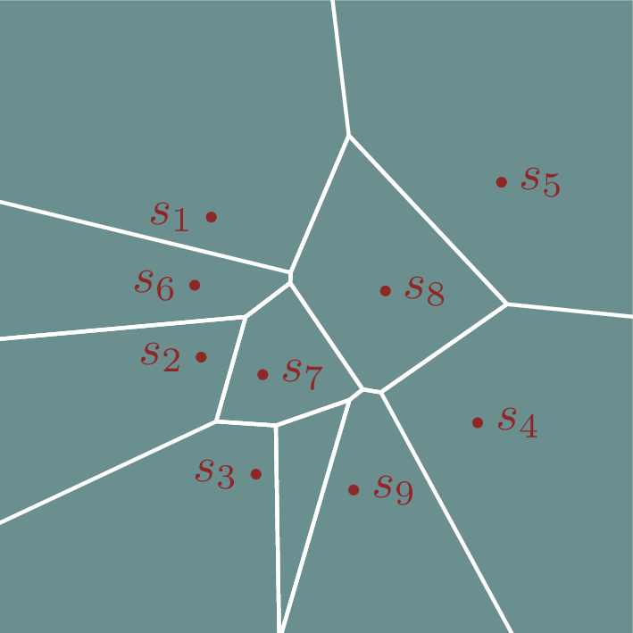

(a)

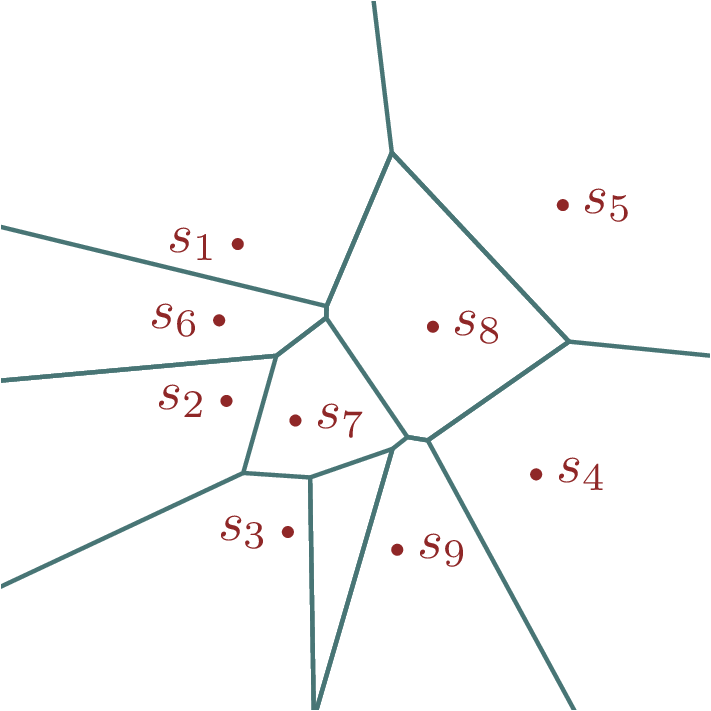

(b)

Figure 1: (a) A Voronoi diagram defined by a collection of sites $( s_{1}, \ldots, s_{N} )$, here shown in red, is a collection of subsets, each containing points that are closer to one site than the others. (b) The boundary between these subsets consists of points that are equally distant to two or more sites at the same time.

The standard Voronoi diagram considers the Euclidean distance function,
$$d( p, p' ) = \sqrt{ (x - x')^{2} + (y - y')^{2} }.$$
In theory, however, this construction can be generalized to other distance functions. At the same time Voronoi diagrams can be defined on higher-dimensional real spaces and even more general non-Euclidean ometric spaces.

A Voronoi diagram *almost* forms partition of a Euclidean plane. The snag is that points that are equally distant from two or more sites don’t fall into any of the cells, but rather form a singular boundary between the cells. The combination of the Voronoi cells and the boundary between them, however, does form a proper partition.

Because each cell contains one, and only one, site, we can always label the cells by the associated site (Figure 2 (a)). Similarly we can label the linear segment that forms the boundary between two neighboring cells by the sites associated with those two cells, and the points separating the corners of three or more neighboring cells by the sites associated with those cells (Figure 2 (b), Figure 2 (b)).

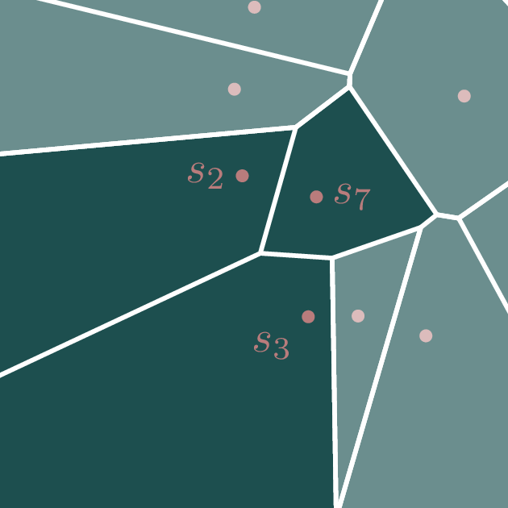

(a)

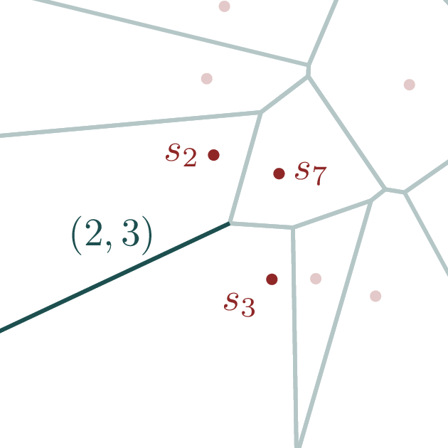

(b)

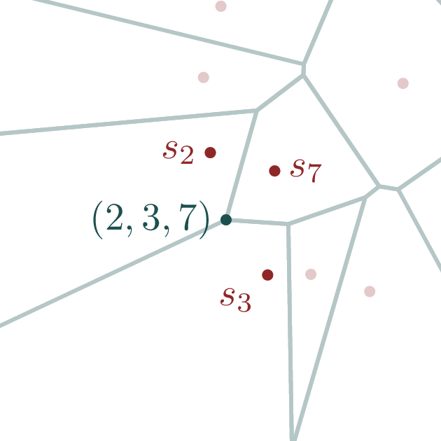

(c)

Figure 2: (a) Each of the cells in a Voronoi diagram can be labeled with the unique site that it contains. (b, c) Similarly the boundaries between neighboring cells can be labeled with the sites contained by those cells. For the purposes of labeling the the order of the sites is arbitrary; here $(3, 2)$ is just as good as $(2, 3)$ while $(2, 7, 3)$, $(3, 7, 2)$, $(3, 2, 7)$, $(7, 3, 2)$, and $(7, 2, 3)$ are just as good as $(2, 3, 7)$.

# 2 The Geometry of Voronoi Diagrams

The boundary between the cells of a Voronoi diagram is useful in its own right. In particular it defines an undirected graph, with linear edges separating neighboring pairs of cells and punctual vertices separating neighboring triplets of cells.

In practice it is often easier to construct this **Voronoi graph** and then derive the Voronoi cells from it rather than trying to construct the Voronoi cells directly. The vertices and edges of the Voronoi graph exhibit rich geometric structure that provides the foundation for powerful construction algorithms.

## 2.1 Voronoi Vertices

The vertices of the Voronoi graph are defined by points that are the same distance from three neighboring Voronoi cells (Figure 3). Consequently we can uniquely label each vertex with a triplet the sites contained by those cells,
$$(s_{n_{1}}, s_{n_{2}}, s_{n_{3}} ).$$
Because not every triplet of Voronoi cells are neighbors, however, not every triplet of sites defines a valid vertex. Fortunately Euclidean geometry provides tools for distinguishing the valid vertices.

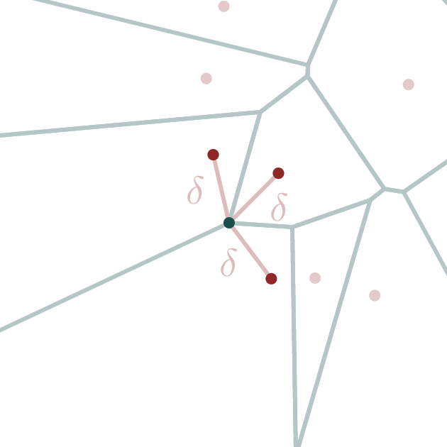

Figure 3: Each vertex in a Voronoi graph is given by a point on the boundary between three neighboring Voronoi cells. This point is by definition equally distant to the sites contained by those cells.

Any triplet of distinct points falls onto a unique **circumcircle** with center
$$\begin{align*}
x_{c}
&=
\frac{1}{2}
\frac{
\left( x_{n_{1}}^{2} + y_{n_{1}}^{2} \right) \,
(y_{n_{2}} - y_{n_{3}})
+ \left( x_{n_{2}}^{2} + y_{n_{2}}^{2} \right) \,
(y_{n_{3}} - y_{n_{1}})
+ \left( x_{n_{3}}^{2} + y_{n_{3}}^{2} \right) \,
(y_{n_{1}} - y_{n_{2}})
}{
x_{n_{1}} \, (y_{n_{2}} - y_{n_{3}} )
+ x_{n_{2}} \, (y_{n_{3}} - y_{n_{1}} )
+ x_{n_{3}} \, (y_{n_{1}} - y_{n_{2}} )
}
\\
y_{c}
&=
\frac{1}{2}
\frac{
\left( x_{n_{1}}^{2} + y_{n_{1}}^{2} \right) \,
(x_{n_{3}} - x_{n_{2}})
+ \left( x_{n_{2}}^{2} + y_{n_{2}}^{2} \right) \,
(x_{n_{1}} - x_{n_{3}})
+ \left( x_{n_{3}}^{2} + y_{n_{3}}^{2} \right) \,
(x_{n_{2}} - x_{n_{1}})
}{
x_{n_{1}} \, (y_{n_{2}} - y_{n_{3}} )
+ x_{n_{2}} \, (y_{n_{3}} - y_{n_{1}} )
+ x_{n_{3}} \, (y_{n_{1}} - y_{n_{2}} )
}
\end{align*}$$
and radius
$$\begin{align*}
r
&=
\sqrt{ (x_{c} - x_{n_{1}})^{2} + (y_{c} - y_{n_{1}})^{2} }
\\
&=
\sqrt{ (x_{c} - x_{n_{2}})^{2} + (y_{c} - y_{n_{2}})^{2} }
\\
&=
\sqrt{ (x_{c} - x_{n_{3}})^{2} + (y_{c} - y_{n_{3}})^{2} }.
\end{align*}$$
Consequently the center of the circumcircle defined by three sites is equidistant to those sites, and hence defines a potential vertex in the Voronoi graph.

The three sites defining a circumcircle are the three *closest* sites to this potential vertex if and only if no other sites are inside of the circumcircle. In other words Voronoi vertices are defined by *empty* circumcircles.

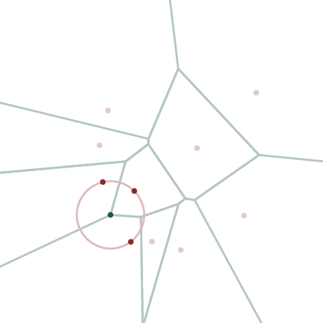

(a)

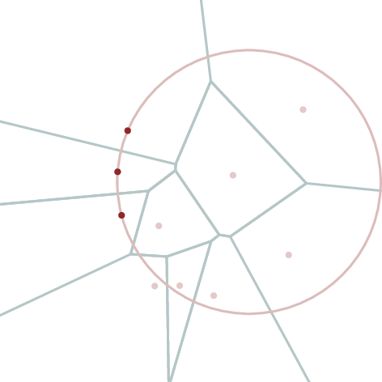

(b)

Figure 4: Not every triplet of sites defines a vertex in a Voronoi graph. (a) Vertices are defined by triplets of sites that define empty circumcircles. (b) Triplets of sites whose circumcircles contain other sites do not define proper vertices.

## 2.2 Voronoi Edges

The edges in a Voronoi graph are comprised of points equidistant to two neighboring cells (Figure 5), allowing us to uniquely label each Voronoi edge with the pair of sites contained by those cells. Once, again, however, we have to take care because arbitrary pairs of sites do not always define valid edges.

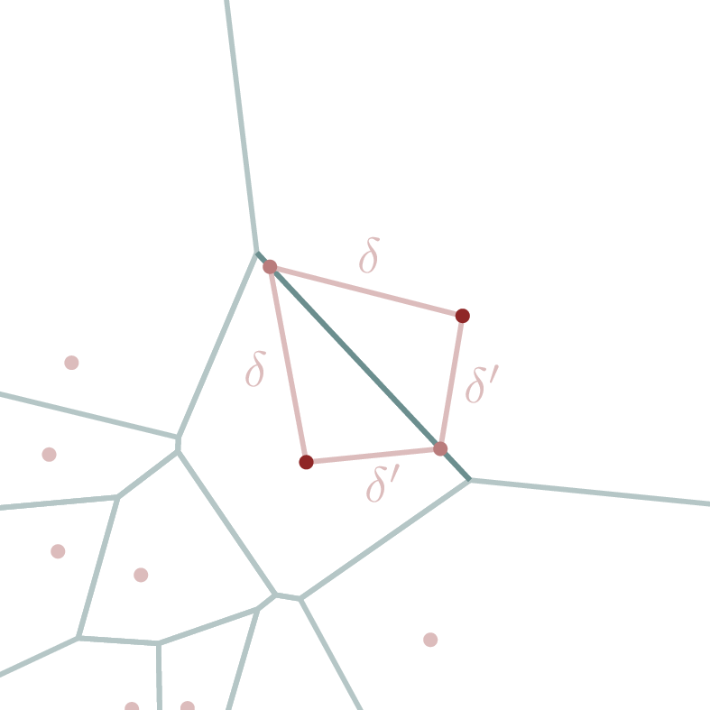

Figure 5: Each edge in a Voronoi graph is defined by linear boundary between two neighboring Voronoi cells. All of the points on a Voronoi edge are equally distant to the two sites contained by those cells.

Before worrying out isolating proper edges let’s first work out the geometry of potential edges. Any pair of sites defines a line that connects them and a mid point on that line that is equally distant to the sites. The **perpendicular bisector** of two sites is the line perpendicular to this connecting line that intersects with the midpoint (Figure 6 (a)). Every point along the perpendicular bisector between two sites is equally distant from those two sites and, consequently, could contribute to a Voronoi edge (Figure 6 (b)).

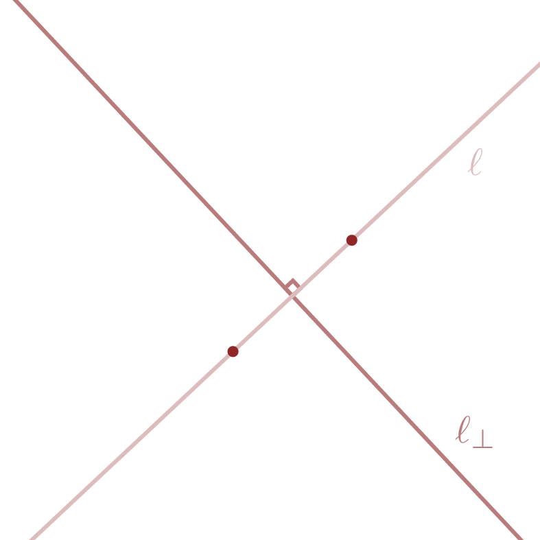

(a)

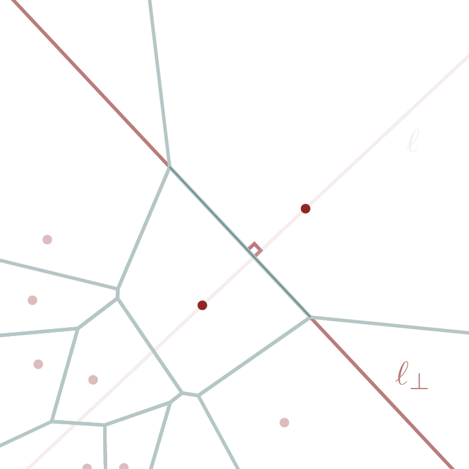

(b)

Figure 6: (a) The perpendicular bisector between two points is the line $\ell_{\perp}$ that is perpendicular to line connecting those points, $\ell$, and intersects the midpoint between them. (b) Every Voronoi edge falls along a perpendicular bisector between two sites, but generally is only a segment of that line. Moreover not every perpendicular bisector contains a Voronoi edge.

In order to determine which segment, if any, of a perpendicular bisector forms a Voronoi edge we come back to circles. Any point along a perpendicular bisector is the center of a unique circle that includes the two defining sites. If no *other* sites are on or inside of this circle then those two sites are the nearest neighbors to each other and that point is, by definition, part of a Voronoi edge.

As we move along the perpendicular bisector these circles will eventually intersect with another site. When they do the point along the bisector will be equally distant to three sites – the two initial sites and this new site – but the interior of the circle will remain empty. In other words the Voronoi edge terminates as soon as we hit a Voronoi vertex.

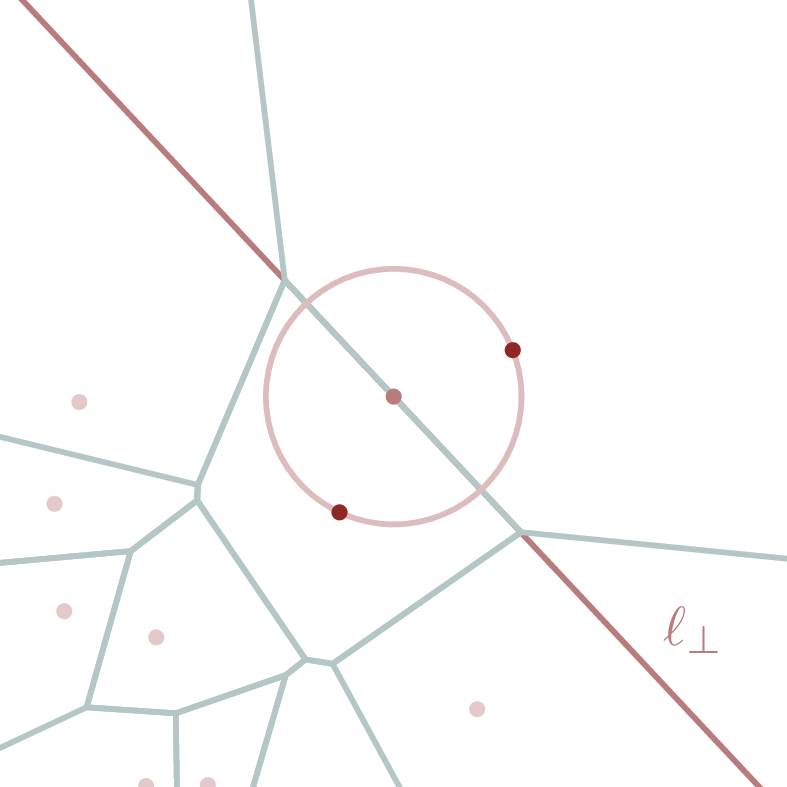

(a)

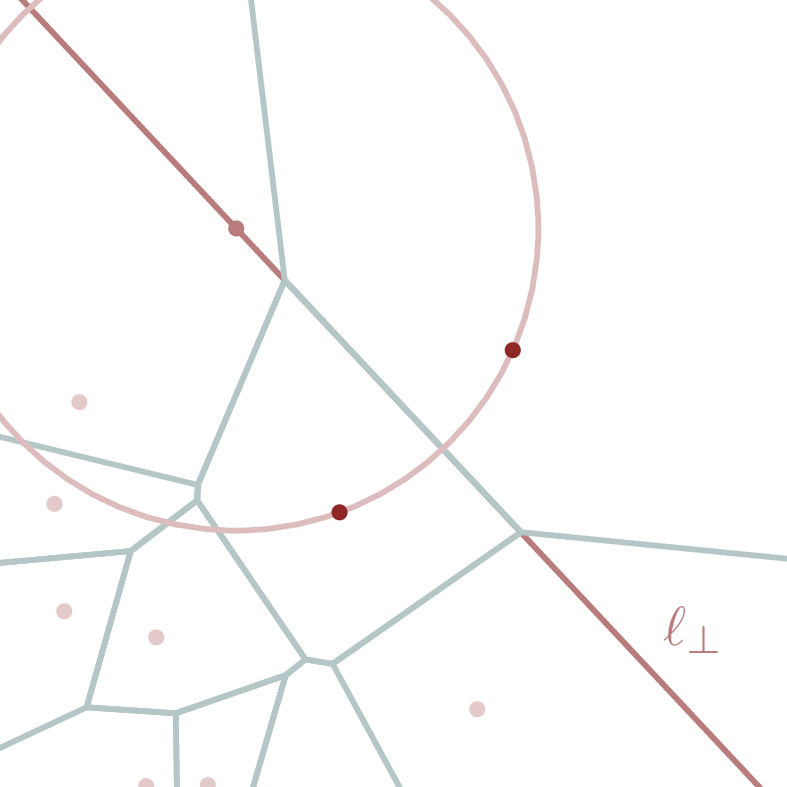

(b)

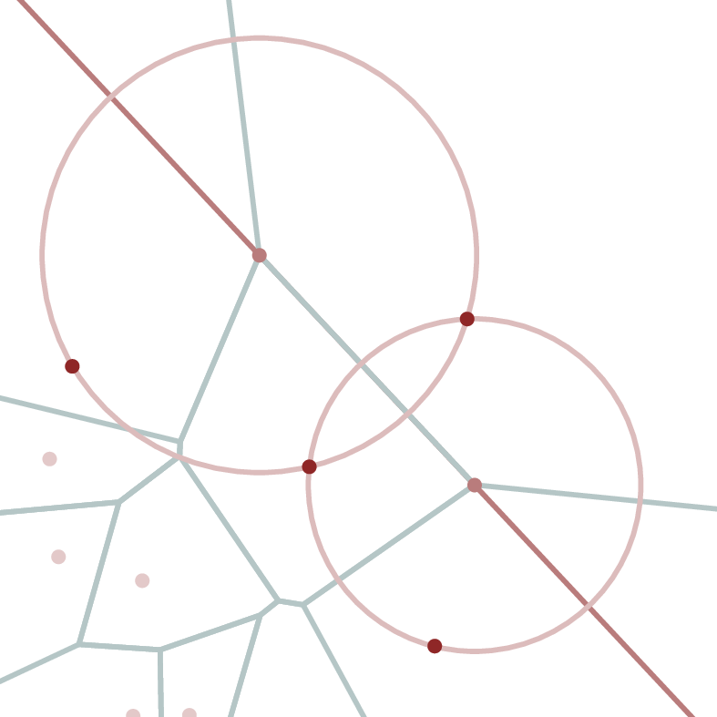

(c)

Figure 7: Circles centered at points along a perpendicular bisector and intersecting with a pair of sites are useful for identifying contributions to Voronoi edges. (a) If there are no other sites on or inside of the circle then the center is part of a Voronoi edge. (b) If there is one or more sites inside of the circle then the center does not contribute to a Voronoi graph at all. (c) If there is another site on the circle then the center defines a Voronoi vertex. Each Voronoi edge terminates when these circles first meet a third site.

## 2.3 Voronoi Faces

The edges of a Voronoi graph trace around each site, defining faceted **faces** in the graph that correspond to the Voronoi cells (Figure 8). When working over the entire, unbounded, Euclidean plane not all of these faces will be closed. While some of the sites will be entirely enclosed by a path of edges, some will be bounded on only one side by a path of edges. I will refer to these as closed faces and open faces, respectively.

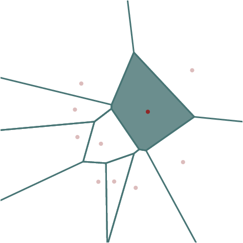

(a)

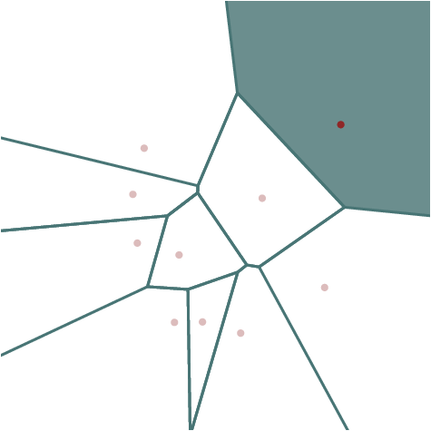

(b)

Figure 8: The edges of a Voronoi graph trace out faces which identify the Voronoi cells. (a) I will refer to faces that are completely enclosed by edges as closed faces and (b) faces that are only partially enclosed as open faces.

# 3 Fortune’s Algorithm

There are here are multiple ways to construct a Voronoi graph, but most of them suffer from wasteful computation. For large enough numbers of sites these approaches quickly become too expensive to be practical. Fortunately there is one elegant approach that, while not at all initially obvious, is able to construct a Voronoi graph as efficiently as possible.

## 3.1 Inefficient Approaches

Before diving into an efficient solution let’s consider some of the more straightforward but ultimately inefficient approaches.

One way to identify all of the vertices in a Voronoi graph is to loop over each triplet of sites and then construct the corresponding circumcircles. For each of these circumcircles we then loop over the remaining sites to check for inclusion, with the centers of the empty circumcircles defining vertices.

We could then construct candidate Voronoi edges by looping over each pair of sites and checking to see if they are associated with any vertices. For each valid pair we could scan across the corresponding perpendicular bisector, construct circles, and check if any other sites appear on or within them.

We can, however, do even better. By systematically scanning across a plane **Fortune’s algorithm** Berg et al. (2008) is able construct a Voronoi graph with a number of operations proportional to $N \log N$. This performance turns out to be theoretically optimal. The main downside of Fortune’s algorithm is that is requires some care to understand and then implement in a way that achieves that optimal scaling.

## 3.2 The Sweep Line

Fortune’s algorithm processes the sites not by working through a list but rather by geometrically scanning across the ambient plane with the use of a **sweep line**. Sites on one side of the sweep line are **active** and can contribute to the construction of the Voronoi graph while sites on the other side are **inactive** and cannot yet contribute. As the sweep line progresses more sites are processed and more of the Voronoi graph is built up.

In theory a sweep line can progress in any direction, but most references consider vertical lines that scan horizontally from left to right, horizontal lines that scan vertically from top to bottom, or horizontal lines that scan vertically from bottom to top. These axis-aligned orientations of the sweep line make geometric calculations substantially more straightforward.

Here I will consider a vertical sweep line that scans horizontally from left to right and denote the horizontal position of the sweep line at any time by $S$.

## 3.3 The Beach Line

A sweep line partitions the ambient plane into two subsets, one containing all of the active sites and one containing all of the inactive sites. This allows us to focus the construction of the Voronoi graph on just one subset of the entire plane and ignore the other. That said, not all of the Voronoi graph to the left of the sweep line is completely determined by the active sites; some features of the Voronoi diagram can be influenced by inactive sites just beyond the sweep line.

Consider, for example, a single active site
$$s_{n} = (x_{n}, y_{n})$$
and the sweep line position
$$S > x_{n}.$$
If a point $(x, y)$ to the left of the sweep line is closer to $s_{n}$ than the sweep line,
$$(x - x_{n})^{2} - (y - y_{n})^{2} < (S - x)^{2},$$
then we it will be closer to $s_{n}$ than any other site that might be hiding beyond the sweep line. On the other hand any point to the left of the sweep line that is closer to the sweep line than it is to $s_{n}$,
$$(x - x_{n})^{2} - (y - y_{n})^{2} > (S - x)^{2},$$
*could* be be closer to an inactive site on the other side of the sweep line that we have not yet taken into account.

Consequently when determining site proximity we cannot analyze the entire region to the left of the sweep line. Instead we can analyze only the subset of points that are closer to $s_{n}$ than they are to the sweep line. The boundary of this analyzable subset is defined by the points equidistant to $s_{n}$ and the sweep line, which traces out the rotated parabola (Figure 9)
$$x
=
f(y)
=
\frac{1}{2}
\left( S + x_{n} - \frac{( y - y_{n} )^{2}}{S - x_{n}} \right).$$

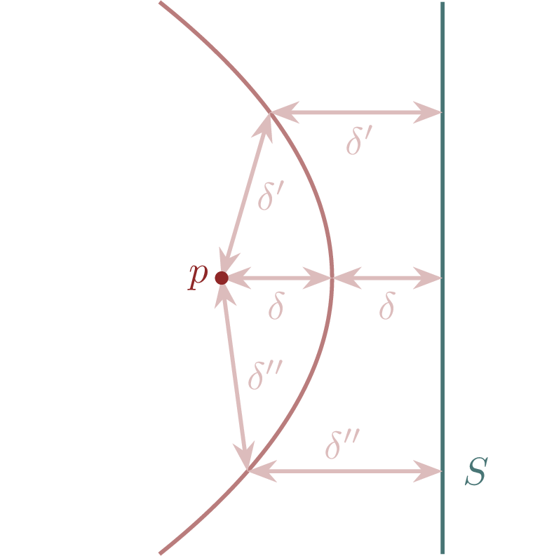

Figure 9: The subset of points that are equally distant from a focus, $s$, and a vertical line $S$, form a rotated parabola. In Fortune’s algorithm the points to the left of this parabola are safe to analyze for their contribution to the Voronoi graph.

When there are multiple active sites then the region that we can safely analyze is comprised of the points that are closer to *any* of the active sites than they are to the sweep line. The boundary of this region is defined by the segmented envelope of the parabolas between each active site and the sweep line (Figure 10). Given its resemblance to the shape made by waves washing up on a beach (Figure 11) this boundary is known as the **beach line**.

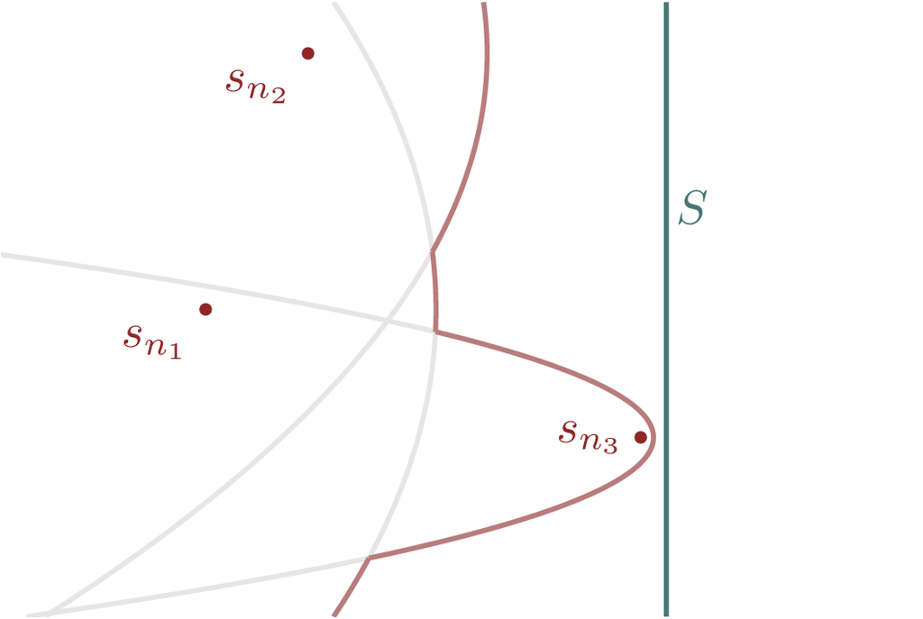

Figure 10: The beach line is the boundary separating points that are closer to any active site, here $s_{n_{1}}$, $s_{n_{2}}$, and $s_{n_{3}}$, and points that are closer to the the sweep line, $S$. This boundary is comprised of a sequence of intersecting parabolic arcs. Note that the parabola between $s_{n_{1}}$ and $S$ contributes multiple arcs to the beach line here.

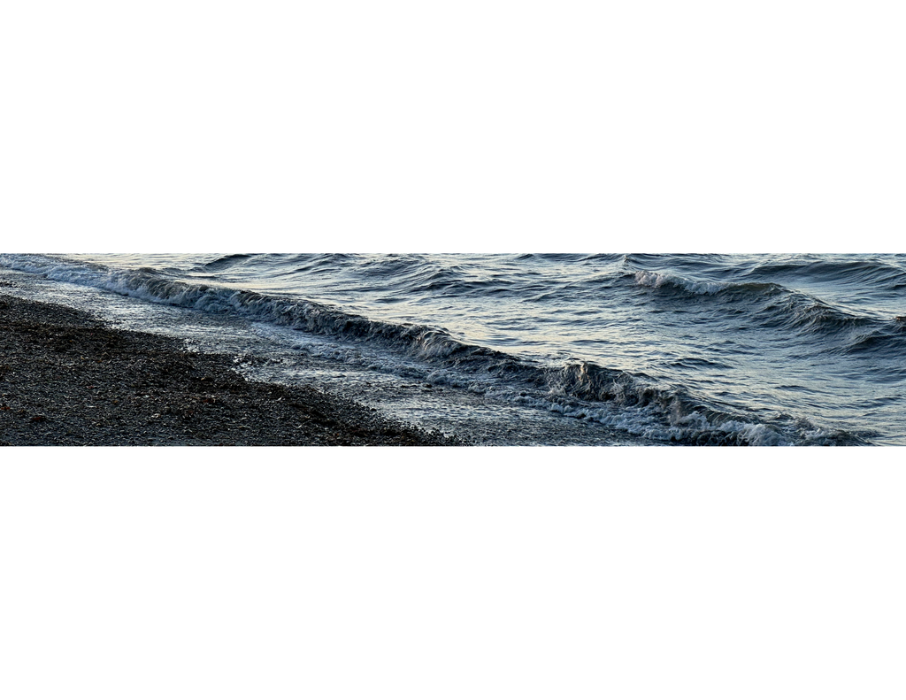

Figure 11: The parabolic arcs that make up a beach line are similar to the shape made by waves washing up onto a beach, hence the name. Photo :copyright: Michael Betancourt.

Each parabolic segment, or **arc**, in a beach line is associated with a single site. The parabola between any given site and the sweep line, however, can contribute to the beach line multiple times. Consequently we cannot use the originating sites to *uniquely* label the arcs.

Neighboring arcs on the beach line are generated from neighboring sites. The discontinuities along the beach line that separate each pair of neighboring arcs are known as **breakpoints** (Figure 12). Each breakpoint is uniquely labeled by an ordered pair of the sites associated with those arcs. Note that ordering is important here: $(s_{n_{1}}, s_{n_{2}})$ and $(s_{n_{2}}, s_{n_{1}})$ correspond to two *different* breakpoints.

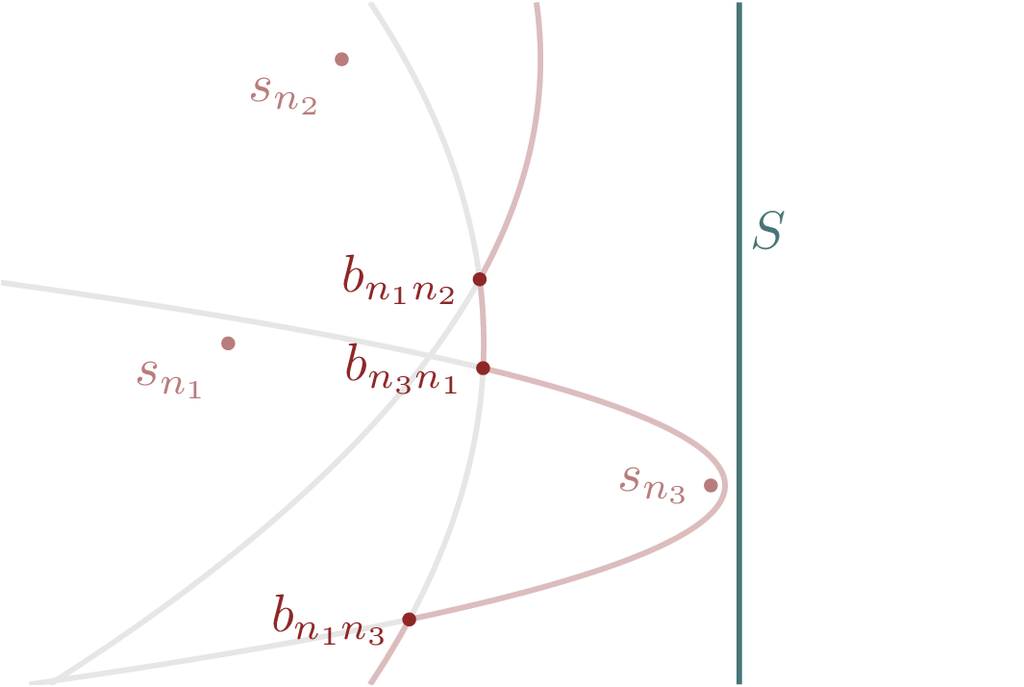

Given a sweep line position $S$ we can readily calculate the intersection of each pair of neighboring parabolas, and hence the position of the corresponding breakpoint. The vertical position $y$ where the two parabolas generated by $s_{n_{1}}$ and $s_{n_{2}}$ intersect is implicitly given by the quadratic equation
$$\begin{align*}
0
&=\quad
\Bigg( \underbrace{ x_{n_{2}} - x_{n_{1}} }_{a} \Bigg) \,
y^{2}
\\
&\quad
-2 \,
\Bigg( \underbrace{ y_{n_{2}} \, (S - x_{n_{1}})
- y_{n_{1}} \, (S - x_{n_{2}}) }_{b} \Bigg) \,
y
\\
&\quad
+
\Bigg( \underbrace{ y_{n_{2}}^{2} \, (S - x_{n_{1}})
- y_{n_{1}}^{2} \, (S - x_{n_{2}})
- (S - x_{n_{1}}) \,
(S - x_{n_{2}}) \,
(x_{n_{2}} - x_{n_{1}} ) }_{c}
\Bigg),
\end{align*}$$
which admits two solutions,
$$y_{\pm} = b \pm \frac{1}{2 \, a} \sqrt{ b^{2} - a \, c }.$$

To determine which of these solutions is associated with the breakpoint $b_{n_{1}n_{2}}$, and hence which is associated with $b_{n_{2}n_{1}}$, we’ll need to consider the relative position of the sites.

If $s_{n_{1}}$ is ahead of $s_{n_{2}}$,
$$x_{n_{1}} > x_{n_{2}}$$
then the breakpoint $b_{n_{1}n_{2}}$ will be *above* the breakpoint $b_{n_{2}n_{1}}$ (Figure 13 (a)). In this case
$$a = x_{n_{2}} - x_{n_{1}}$$
is negative so the higher solution is given by
$$y_{n_{1}n_{2}}
=
y_{-}
=
b - \frac{1}{2 \, a} \sqrt{ b^{2} - a \, c }.$$

On the other hand if $s_{n_{1}}$ is behind $s_{n_{2}}$,
$$x_{n_{1}} < x_{n_{2}}$$
then the breakpoint $b_{n_{1}n_{2}}$ will be *below* the breakpoint $b_{n_{2}n_{1}}$ (Figure 13 (b)). Because the leading coefficient is now positive,
$$a = x_{n_{2}} - x_{n_{1}},$$
the appropriate solution is *also* given by
$$y_{n_{1}n_{2}}
=
y_{-}
=
b - \frac{1}{2 \, a} \sqrt{ b^{2} - a \, c }.$$

In other words the the sign of $a$ conveniently adjusts the geometry correctly so that we can *always* take
$$y_{n_{1}n_{2}}
=
b - \frac{1}{2 \, a} \sqrt{ b^{2} - a \, c }$$
and
$$y_{n_{2}n_{1}}
=
b + \frac{1}{2 \, a} \sqrt{ b^{2} - a \, c }.$$

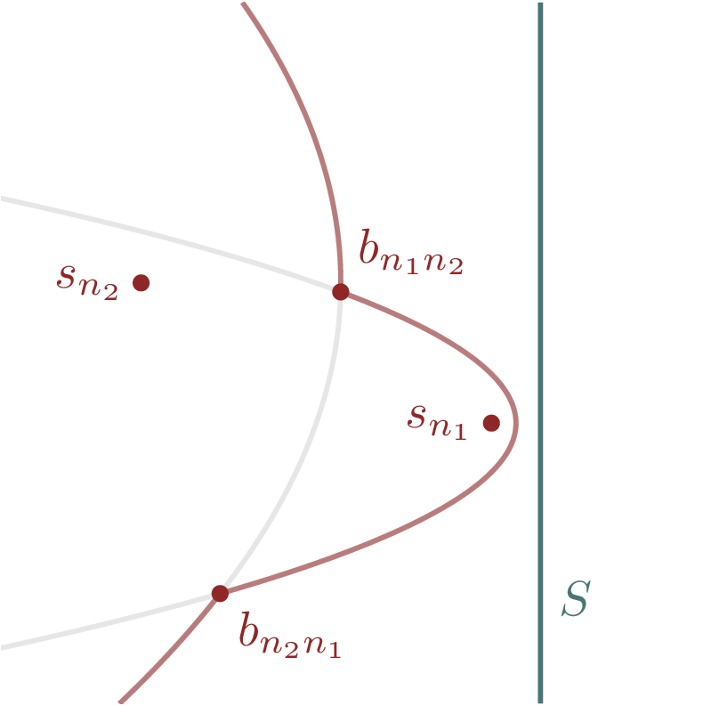

(a)

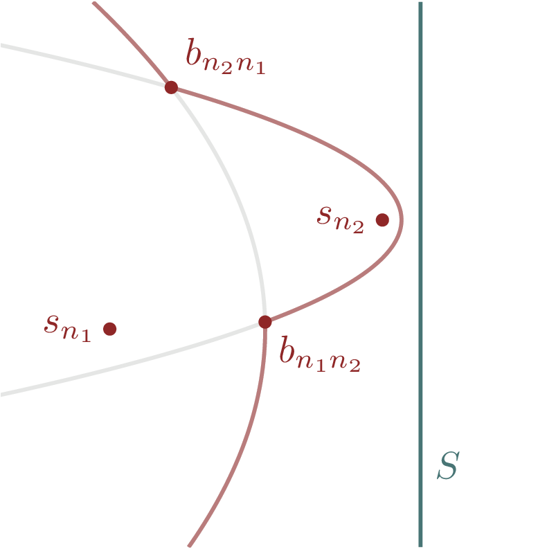

(b)

Figure 13: The parabolas defined by two points $s_{n_{1}}$ and $s_{n_{2}}$ intersect at two different points, one of which gives the breakpoint $b_{n_{1}n_{2}}$ and the other giving $b_{n_{2}n_{1}}$. (a) If $x_{n_{1}} > x_{n_{2}}$ then $b_{n_{1}n_{2}}$ is given by the higher of the two intersections, but (b) if $x_{n_{1}} < x_{n_{2}}$ then $b_{n_{1}n_{2}}$ is given by the lower of the two intersections.

When it comes to constructing Voronoi graphs the breakpoints are the most important part of the beach line. Because they always falls onto the parabolas generated by two neighboring sites, each breakpoint is equally distant from those two sites and the sweep line. At the same time each breakpoint is further from all other active sites as well as any inactive sights hiding beyond the sweep line.

All of this is to say that, by construction, every breakpoint is the center of a circle containing the two associated sites but includes no other sites. In other words, each breakpoint *always falls on a Voronoi edge no matter the position of the sweep line*. Specifically the breakpoints $b_{n_{1}n_{2}}$ and $b_{n_{2}n_{1}}$ both fall on the Voronoi edge between $s_{n_{1}}$ and $s_{n_{2}}$.

## 3.4 Evolving The Beach Line

As we scan the sweep line across a Euclidean plane the distances between the active sites and the sweep line will change. This, in turn, changes the shape of the corresponding parabolas and, ultimately, the shape of the beach line. As the beach line evolves the breakpoints trace out the Voronoi edges, incrementally generating the entire Voronoi graph!

Every now and then the number of arcs comprising the beach line, known as the **topology** of the beach line, also changes. When the sweep line passes over a new site, for example, a new arc is added to the beach line. Similarly arcs can be removed from the beach line when they are squeezed to a point by their neighboring arcs.

Conveniently we don’t need to *continuously* scan the sweep line in order to construct a Voronoi diagram. The structure of a Voronoi diagram is completely determined by the behavior of the beach line at the finite number of sweep line positions where the topology changes. If we can efficiently determine these topology-changing **events** then we can efficiently build up a Voronoi diagram in a finite number of operations.

### 3.4.1 Events Where The Beach Line Expands

Whenever the sweep line crosses a new site, that site becomes active and contributes a new parabolic arc to the beach line. Because we know the position of all of the sites we know at exactly which positions these **site events** will occur.

If the sweep line is positioned on a new site then the parabola of points equidistant from that site and the sweep line is singular, consisting of just the new site itself. This forms a point discontinuity with the rest of the beach line (Figure 14 (a)). Although not *technically* correct, these singular arcs are often visualized with a horizontal line extending from the new site to the beach line (Figure 14 (b)).

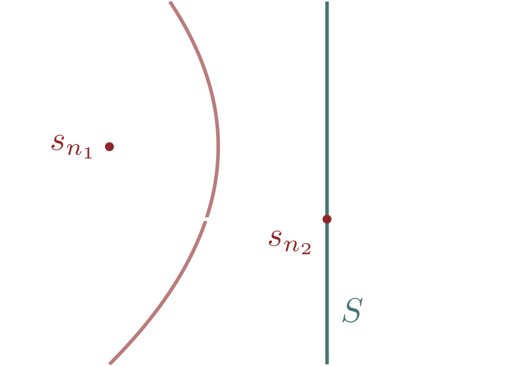

(a)

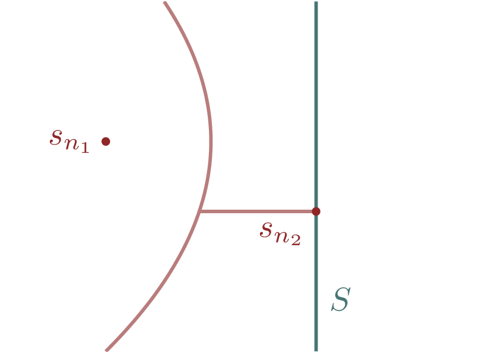

(b)

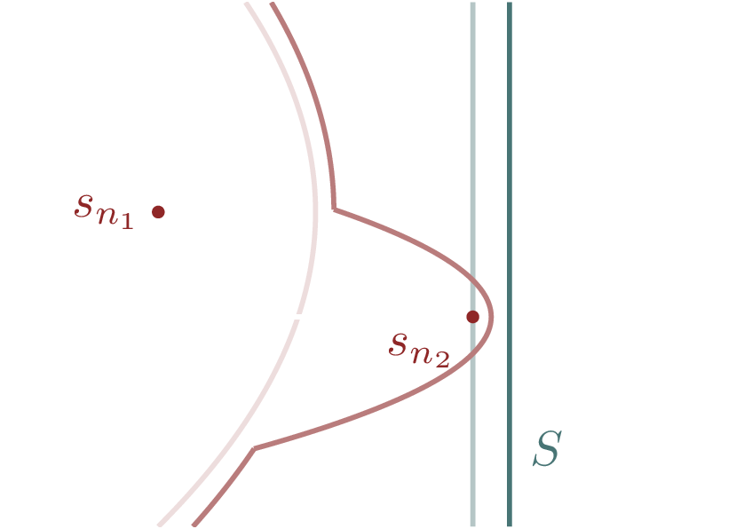

(c)

Figure 14: At a site event the sweep line hits an inactive site which then becomes active. (a) Initially the new active site introduces a new singular arc which splits the beach line. (b) This singular arc is often visualized with a continuous horizontal line. (c) As the sweep line proceeds past the site event, this singular arc widens into a well-behaved parabola, separating one of the beach line arcs into two arcs.

As the sweep line progresses past the new active site, the singular parabola widens into a more well-behaved parabola (Figure 14 (c)). This not only restores the continuity of the beach line but also splits an existing parabolic arc into two new arcs. The introduction of a new active site always splits an existing arc into a triplet of arcs, the outer two of which are generated by the same site.

For example let’s say that the sweep line passes the new site $s_{n_{2}}$. If the height of this site $y_{n_{2}}$ intersects with an arc generated by the site $s_{n_{1}}$ then the site event will split that arc into a triplet of arcs, the outer two of which are generated by $s_{n_{1}}$ and the center of which is generated by $s_{n_{2}}$. These three arcs are then separated by two new breakpoints $b_{ n_{1} n_{2} }$ and $b_{ n_{2} n_{1} }$.

Both of these new breakpoints fall on a Voronoi edge in between the sites $s_{n_{1}}$ and $s_{n_{2}}$. As the sweep line progresses the middle arc widens and the breakpoints separate, tracing out more and more of that edge (Figure 15).

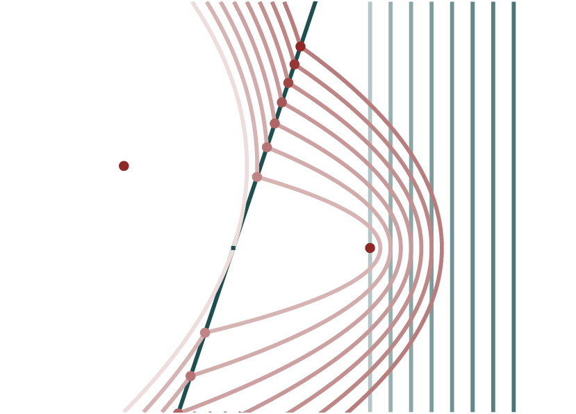

Figure 15: As the sweep line moves past a site event, the two new breakpoints separate and scan across the Voronoi edge between the two neighboring sites.

### 3.4.2 Events Where The Beach Line Contracts

The topology of the beach line can also change when one of the parabolic arcs collapses in between its two neighboring arcs (Figure 16). In this case the collapsed arc is removed from the beach line and its two neighboring arcs become new neighbors.

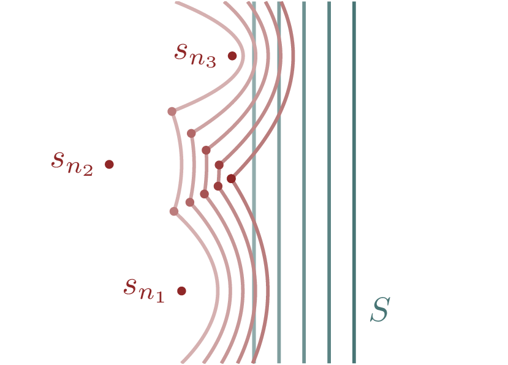

Figure 16: As the sweep line progresses, arcs on the beach line can collapse in between their two neighboring arcs. When this happens the neighboring breakpoints converge to a point. This convergence point is equally distant from the three active sites but further from all other sites, defining a vertex in the Voronoi graph.

Consider three neighboring arcs generated from the active sites $s_{n_{2}}$, $s_{n_{2}}$, and $s_{n_{3}}$. If any two of these sites are the same then the central arc will not collapse as the sweep line progresses so we can safely assume that these sites are distinct.

When the central arc collapses its two neighboring breakpoints $b_{ n_{1} n_{2} }$ and $b_{ n_{2} n_{3} }$ will merge into a new breakpoint $b_{ n_{1} n_{3} }$. At that moment
$$b_{ n_{1} n_{2} } = b_{ n_{2} n_{3} } = b_{ n_{1} n_{3} }$$
are equally distant from $s_{n_{2}}$, $s_{n_{2}}$, and $s_{n_{3}}$. Because this intersection is on the beach line it also cannot be closer to any inactive sites hiding beyond the sweep line. In other words a collapsing arc on the beach line always defines a Voronoi vertex!

This duality between arc collapses and Voronoi vertices is useful not only for building up the Voronoi graph but also for predicting when arcs will collapse. By now it should be no surprise that this prediction will involve circles.

For any triplet of neighboring arcs that correspond to the distinct sites $s_{n_{1}}$, $s_{n_{2}}$, and $s_{n_{3}}$ we can always construct a unique circumcircle with center $(x_{c}, y_{c})$ and radius $r$. By construction the center $(x_{c}, y_{c})$ is equally distant to all three sites, and hence identifies exactly where the central arc will collapse to a point.

The center is also equally distant to vertical lines at $x = x_{c} - r$ and $x = x_{c} + r$, which define the two possible sweep line configurations where the central arc will collapse. When $S = x_{c} - r$, however, the sweep line will not yet have reached any of the three sites and they will not yet have contributed any arcs to the beach line. Consequently a central arc generated by $s_{n_{2}}$ can collapse only when $S = x_{c} + r$ (Figure 17).

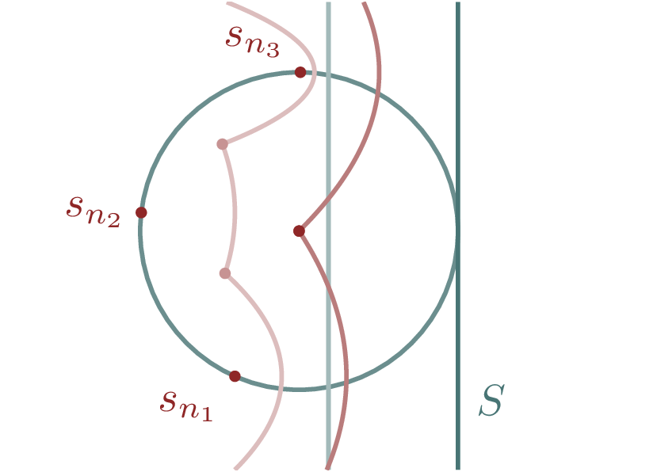

Figure 17: If the central arc in a triplet of neighboring arcs collapses then it will do so when the sweep line is at the far edge of the circumcircle spanned by those three sites. This geometric extrapolation allows us to schedule future vertex events.

That said, this collapse can contribute to the Voronoi graph only if it occurs to the right of the beach line, where the structure of the Voronoi graph has not yet been established. If $x_{c}$ falls to the left of the current beach line then advancing the sweep line forward will cause the central arc to not collapse but rather expand, with the breakpoints *diverging* away from each other.

One particularly straightforward way to determine if a central arc will collapse as the sweep line progresses forward is to directly check if $y_{ n_{1} n_{2} } = y_{ n_{2} n_{3} }$ at $S = x_{c} + r$. While this works fine in theory, it can be awkward to implement in practice as checking the equality of two floating point numbers is always tricky.

We can also use the relative positions of $s_{n_{1}}$, $s_{n_{2}}$, and $s_{n_{3}}$ to determine whether some arcs will converge or diverge. For example if site $s_{n_{2}}$ is *behind* both $s_{n_{1}}$ and $s_{n_{3}}$,
$$\begin{align*}
x_{n_{2}} &< x_{n_{1}}
\\
x_{n_{2}} &< x_{n_{3}},
\end{align*}$$
then the Voronoi edges, and the breakpoints that flow along them, will converge (Figure 18 (a)). On the other hand if $s_{n_{2}}$ is *ahead* of the other two sites,
$$\begin{align*}
x_{n_{2}} &> x_{n_{1}}
\\
x_{n_{2}} &> x_{n_{3}},
\end{align*}$$
then the Voronoi edges will diverge, pulling the breakpoints away from each other (Figure 18 (b)).